# simulaçao

```python
import matplotlib.pyplot as plt
import numpy as np
import scienceplots
plt.rcParams['text.usetex'] = False
plt.style.use(['science', 'notebook', 'grid'])
```

$q_{1}=-1 \times 10^{-5}\; \mathrm{C}, \quad \overrightarrow{r}_{1}=(0 ;-1)\; \mathrm{m}$

$q_{2}=+2 \times 10^{-5}\; \mathrm{C}, \quad \overrightarrow{r}_{2}=(0 ; 1)\; \mathrm{m}$

$q_{3}=+3 \times 10^{-5}\; \mathrm{C}, \quad \overrightarrow{r}_{3}=(1 ; 0) \;\mathrm{m}$

$q_{4}=-4 \times 10^{-5}\; \mathrm{C}, \quad \overrightarrow{r}_{4}=(-1 ; 0)\; \mathrm{m}$

```python
x=np.array([0])
y=np.array([0])
v_x=np.array([0])
v_y=np.array([0])

a_x=np.array([])
a_y=np.array([])

q=1*10**-5
k_0=8.9875517923*10**9

x_qfixas=np.array([0,0,1,-1])
y_qfixas=np.array([-1,1,0,0])
q_fixas=np.array([-1,+2,+3,-4])*10**-5
```

Calculo $F_x$ e $a_x$ iniciais:

$\overrightarrow{F}_{x_i}(0) = k_0 \frac{q \cdot q_i \cdot [x(0)-x_i]}{\left(\sqrt{[x_i - x(0)]^2 + [y_i - y(0)]^2}\right)^3}$

$\overrightarrow{F}_{x}(0) = \sum_{i=1}^4 \overrightarrow{F}_{x_i}(0)$

$\overrightarrow{a}_x(0) = \overrightarrow{F}_{x}(0)$

```python
f_x_vetor=k_0*(q*q_fixas)*(x[0]-x_qfixas)/((x_qfixas-x[0])**2+(y[0]-y_qfixas)**2)**1.5
f_x=sum(f_x_vetor)
a_x=np.append(a_x,f_x)
```

Calculo $F_y$ e $a_y$ iniciais:

$\overrightarrow{F}_{y_i}(0) = k_0 \frac{q \cdot q_i \cdot [y(0) - y_i ]}{\left(\sqrt{[x_i - x(0)]^2 + [y_i - y(0)]^2}\right)^3}$

$\overrightarrow{F}_{y}(0) = \sum_{i=1}^4 \overrightarrow{F}_{y_i}(0)$

$\overrightarrow{a}_y(0) = \overrightarrow{F}_{y}(0)$

```python
f_y_vetor=k_0*(q*q_fixas)*(y[0]-y_qfixas)/((y_qfixas-y[0])**2+(x[0]-x_qfixas)**2)**1.5
f_y=sum(f_y_vetor)
a_y=np.append(a_y,f_y)
```

Representação das condições iniciais:

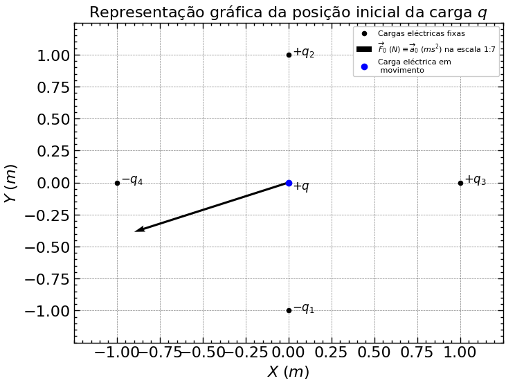

```python
plt.scatter(x_qfixas,y_qfixas,s=20,color="black",label=r"Cargas eléctricas fixas")
plt.quiver(0, 0, f_x, f_y, angles='xy', scale_units='xy', scale=7, width=0.005, color='black',
label=r"$\overrightarrow{F}_0\;(N)\equiv \overrightarrow{a}_0\;(ms^2) $ na escala 1:7")

plt.scatter(0,0,color="blue",label="Carga eléctrica em \n movimento")
plt.xlabel(r'$X \; (m)$')
plt.ylabel(r'$Y \; (m)$')

plt.text(0.02, -1, rf'$-q_1$', fontsize=12)
plt.text(0.02, 1, rf'$+q_2$', fontsize=12)
plt.text(1.02, 0, rf'$+q_3$', fontsize=12)
plt.text(-0.98, 0, rf'$-q_4$', fontsize=12)
plt.text(0.02, -0.05, rf'$+q$', fontsize=12)



plt.xlim(-1.25, 1.25)
plt.ylim(-1.25, 1.25)

plt.xticks(np.arange(-1, 1.25, 0.25))
plt.yticks(np.arange(-1, 1.25, 0.25))

plt.title(r"Representação gráfica da posição inicial da carga $q$",fontsize=16)
plt.legend(fontsize=8)
```

Calculo das N iterações:

$x(n+1)=x(n)+v_x(n) \Delta t+\frac{1}{2} a_x(n)(\Delta t)^{2}$

$y(n+1)=y(n)+v_y(n) \Delta t+\frac{1}{2} a_y(n)(\Delta t)^{2}$

$-------------$

$\overrightarrow{F}_{y_i}(n+1) = k_0 \frac{q \cdot q_i \cdot [y(n+1) - y_i ]}{\left(\sqrt{[x_i - x(n+1)]^2 + [y_i - y(n+1)]^2}\right)^3}$

$\overrightarrow{F}_{y}(n+1) = \sum_{i=1}^4 \overrightarrow{F}_{y_i}(n+1)$

$\overrightarrow{a}_y(n+1) = \overrightarrow{F}_{y}(n+1)$

$-------------$

$\overrightarrow{F}_{x_i}(n+1) = k_0 \frac{q \cdot q_i \cdot [x(n+1)-x_i]}{\left(\sqrt{[x_i - x(n+1)]^2 + [y_i - y(n+1)]^2}\right)^3}$

$\overrightarrow{F}_{x}(n+1) = \sum_{i=1}^4 \overrightarrow{F}_{x_i}(n+1)$

$\overrightarrow{a}_x(n+1) = \overrightarrow{F}_{x}(n+1)$

$-------------$

$ v_x(n+1)=v_x(n)+\frac{1}{2}\left[a_x(n)+a_x(n+1)\right] \Delta t $

$ v_y(n+1)=v_y(n)+\frac{1}{2}\left[a_y(n)+a_y(n+1)\right] \Delta t$

```python
#  Dado que para nós é mais fácil
#  pensar assim, fizemos as seguintes
#  alterações nas equações:
#  n->n-1 e n+1->n
N=1000
Dt=0.01
for n in range(1,N):



 xn=x[n-1]+v_x[n-1]*Dt+0.5*a_x[n-1]*Dt**2 #calculo de x(n)
 yn=y[n-1]+v_y[n-1]*Dt+0.5*a_y[n-1]*Dt**2 #calculo de y(n)

 y=np.append(y,yn) #juntar às listas de valores
 x=np.append(x,xn)


 f_x_vetor=k_0*(q*q_fixas)*(x[n]-x_qfixas)/((x_qfixas-x[n])**2+(y_qfixas-y[n])**2)**1.5
 #calculo de todos os F_xi, retorna um array com os 4

 f_x=sum(f_x_vetor)#soma todos os elementos do array
 a_x=np.append(a_x,f_x)#fx=ax, guarda na lista de ax

 #repete mas para as componentes y
 f_y_vetor=k_0*(q*q_fixas)*(y[n]-y_qfixas)/((y_qfixas-y[n])**2+(x_qfixas-x[n])**2)**1.5
 f_y=sum(f_y_vetor)
 a_y=np.append(a_y,f_y)

 v_xn=v_x[n-1]+0.5*(a_x[n-1]+a_x[n])*Dt#calculo de vx(n)/vy(n)
 v_yn=v_y[n-1]+0.5*(a_y[n-1]+a_y[n])*Dt

 v_y=np.append(v_y,v_yn)#juntar às listas de valores
 v_x=np.append(v_x,v_xn)
```

Construção do gráfico:

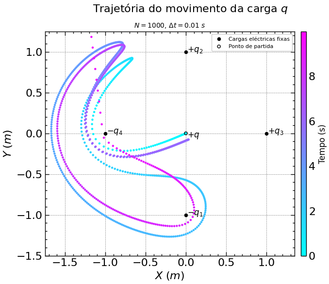

```python
cores=np.arange(N)*Dt
#array para "mapear" as cores

plt.scatter(x,y,s=5,c=cores,cmap="cool")

cbar=plt.colorbar (orientation="vertical",pad=0.02,aspect=40)
#adiciona e formata a barra de cores para representar o tempo

cbar.set_label(label="Tempo (s)", size=12)
#adiciona a legenda à barra de tempo

plt.scatter(x_qfixas,y_qfixas,s=20,color="black",label=r"Cargas eléctricas fixas")
plt.scatter(0,0,s=20, edgecolors='black', facecolors='none',label=r"Ponto de partida")
plt.xlim(-1.75, 1.35)
plt.ylim(-1.50, 1.25)

plt.text(0.02, -1, rf'$-q_1$', fontsize=12)
plt.text(0.02, 1, rf'$+q_2$', fontsize=12)
plt.text(1.02, 0, rf'$+q_3$', fontsize=12)
plt.text(-0.98, 0, rf'$-q_4$', fontsize=12)
plt.text(0.02, -0.05, rf'$+q$', fontsize=12)

plt.xlabel(r'$X \; (m)$')
plt.ylabel(r'$Y \; (m)$')

plt.title(rf"$N={N}$, $\Delta t= {Dt} \; s$",fontsize=10)
plt.suptitle(r"Trajetória do movimento da carga $q$",fontsize=16)
plt.legend(fontsize=8)
```